# Dataset - (Ford GoBike System Data)

## by (NWANAGU James Ifeanyichukwu)

## Introduction

> This data set includes information about individual rides made in a bike-sharing system covering the greater San Francisco Bay area.

## Preliminary Wrangling

> This data contains 183412 Data columns and a total of 16 columns

```python
# import all packages and set plots to be embedded inline
import numpy as np
import pandas as pd
import matplotlib.pyplot as plt
import seaborn as sb
import calendar

%matplotlib inline
```

```python
# load dataset into pandas
gobike = pd.read_csv('201902-fordgobike-tripdata.csv')
```

```python
# Overview of data shape and information about the dataset
print(gobike.shape)
print(gobike.info())
```

```
(183412, 16)
<class 'pandas.core.frame.DataFrame'>
RangeIndex: 183412 entries, 0 to 183411
Data columns (total 16 columns):
duration_sec               183412 non-null int64
start_time                 183412 non-null object
end_time                   183412 non-null object
start_station_id           183215 non-null float64
start_station_name         183215 non-null object
start_station_latitude     183412 non-null float64
start_station_longitude    183412 non-null float64
end_station_id             183215 non-null float64
end_station_name           183215 non-null object
end_station_latitude       183412 non-null float64
end_station_longitude      183412 non-null float64
bike_id                    183412 non-null int64
user_type                  183412 non-null object
member_birth_year          175147 non-null float64
member_gender              175147 non-null object
bike_share_for_all_trip    183412 non-null object
dtypes: float64(7), int64(2), object(7)
memory usage: 22.4+ MB
None
```

```python
# view first five rows of the datasets
gobike.head()
```

|  | duration_sec | start_time | end_time | start_station_id | start_station_name | start_station_latitude | start_station_longitude | end_station_id | end_station_name | end_station_latitude | end_station_longitude | bike_id | user_type | member_birth_year | member_gender | bike_share_for_all_trip |
| --- | --- | --- | --- | --- | --- | --- | --- | --- | --- | --- | --- | --- | --- | --- | --- | --- |
| 0 | 52185 | 2019-02-28 17:32:10.1450 | 2019-03-01 08:01:55.9750 | 21.0 | Montgomery St BART Station (Market St at 2nd St) | 37.789625 | -122.400811 | 13.0 | Commercial St at Montgomery St | 37.794231 | -122.402923 | 4902 | Customer | 1984.0 | Male | No |
| 1 | 42521 | 2019-02-28 18:53:21.7890 | 2019-03-01 06:42:03.0560 | 23.0 | The Embarcadero at Steuart St | 37.791464 | -122.391034 | 81.0 | Berry St at 4th St | 37.775880 | -122.393170 | 2535 | Customer | NaN | NaN | No |
| 2 | 61854 | 2019-02-28 12:13:13.2180 | 2019-03-01 05:24:08.1460 | 86.0 | Market St at Dolores St | 37.769305 | -122.426826 | 3.0 | Powell St BART Station (Market St at 4th St) | 37.786375 | -122.404904 | 5905 | Customer | 1972.0 | Male | No |
| 3 | 36490 | 2019-02-28 17:54:26.0100 | 2019-03-01 04:02:36.8420 | 375.0 | Grove St at Masonic Ave | 37.774836 | -122.446546 | 70.0 | Central Ave at Fell St | 37.773311 | -122.444293 | 6638 | Subscriber | 1989.0 | Other | No |
| 4 | 1585 | 2019-02-28 23:54:18.5490 | 2019-03-01 00:20:44.0740 | 7.0 | Frank H Ogawa Plaza | 37.804562 | -122.271738 | 222.0 | 10th Ave at E 15th St | 37.792714 | -122.248780 | 4898 | Subscriber | 1974.0 | Male | Yes |

```python
# numerical statistics for the dataset
gobike.describe()
```

|  | duration_sec | start_station_id | start_station_latitude | start_station_longitude | end_station_id | end_station_latitude | end_station_longitude | bike_id | member_birth_year |
| --- | --- | --- | --- | --- | --- | --- | --- | --- | --- |
| count | 183412.000000 | 183215.000000 | 183412.000000 | 183412.000000 | 183215.000000 | 183412.000000 | 183412.000000 | 183412.000000 | 175147.000000 |
| mean | 726.078435 | 138.590427 | 37.771223 | -122.352664 | 136.249123 | 37.771427 | -122.352250 | 4472.906375 | 1984.806437 |
| std | 1794.389780 | 111.778864 | 0.099581 | 0.117097 | 111.515131 | 0.099490 | 0.116673 | 1664.383394 | 10.116689 |
| min | 61.000000 | 3.000000 | 37.317298 | -122.453704 | 3.000000 | 37.317298 | -122.453704 | 11.000000 | 1878.000000 |
| 25% | 325.000000 | 47.000000 | 37.770083 | -122.412408 | 44.000000 | 37.770407 | -122.411726 | 3777.000000 | 1980.000000 |
| 50% | 514.000000 | 104.000000 | 37.780760 | -122.398285 | 100.000000 | 37.781010 | -122.398279 | 4958.000000 | 1987.000000 |
| 75% | 796.000000 | 239.000000 | 37.797280 | -122.286533 | 235.000000 | 37.797320 | -122.288045 | 5502.000000 | 1992.000000 |
| max | 85444.000000 | 398.000000 | 37.880222 | -121.874119 | 398.000000 | 37.880222 | -121.874119 | 6645.000000 | 2001.000000 |

```python
# checking how many rider have the minimum 61 seconds trip duration
gobike[gobike['duration_sec'] == 61].count()
```

```
duration_sec               18
start_time                 18
end_time                   18
start_station_id           18
start_station_name         18
start_station_latitude     18
start_station_longitude    18
end_station_id             18
end_station_name           18
end_station_latitude       18
end_station_longitude      18
bike_id                    18
user_type                  18
member_birth_year          18
member_gender              18
bike_share_for_all_trip    18
dtype: int64
```

```python
# view 5 minimum duration
gobike.nsmallest(5, 'duration_sec')
```

|  | duration_sec | start_time | end_time | start_station_id | start_station_name | start_station_latitude | start_station_longitude | end_station_id | end_station_name | end_station_latitude | end_station_longitude | bike_id | user_type | member_birth_year | member_gender | bike_share_for_all_trip |
| --- | --- | --- | --- | --- | --- | --- | --- | --- | --- | --- | --- | --- | --- | --- | --- | --- |
| 18578 | 61 | 2019-02-26 18:23:44.2830 | 2019-02-26 18:24:45.5230 | 368.0 | Myrtle St at Polk St | 37.785434 | -122.419622 | 368.0 | Myrtle St at Polk St | 37.785434 | -122.419622 | 5333 | Subscriber | 1989.0 | Female | No |
| 19581 | 61 | 2019-02-26 16:40:53.1210 | 2019-02-26 16:41:54.4510 | 43.0 | San Francisco Public Library (Grove St at Hyde... | 37.778768 | -122.415929 | 43.0 | San Francisco Public Library (Grove St at Hyde... | 37.778768 | -122.415929 | 5306 | Subscriber | 1987.0 | Female | No |
| 27017 | 61 | 2019-02-25 10:31:18.4150 | 2019-02-25 10:32:19.7480 | 59.0 | S Van Ness Ave at Market St | 37.774814 | -122.418954 | 59.0 | S Van Ness Ave at Market St | 37.774814 | -122.418954 | 5921 | Subscriber | 1972.0 | Male | Yes |
| 44301 | 61 | 2019-02-22 15:09:57.0480 | 2019-02-22 15:10:58.7420 | 310.0 | San Fernando St at 4th St | 37.335885 | -121.885660 | 280.0 | San Fernando St at 7th St | 37.337122 | -121.883215 | 6347 | Subscriber | 1989.0 | Male | Yes |
| 44787 | 61 | 2019-02-22 13:56:21.9760 | 2019-02-22 13:57:23.4650 | 30.0 | San Francisco Caltrain (Townsend St at 4th St) | 37.776598 | -122.395282 | 81.0 | Berry St at 4th St | 37.775880 | -122.393170 | 6150 | Subscriber | 1931.0 | Male | No |

```python
# checking how many rider have the maximum 85444 seconds trip duration which is 23:73 hours
gobike[gobike['duration_sec'] == 85444].count()
```

```
duration_sec               1
start_time                 1
end_time                   1
start_station_id           1
start_station_name         1
start_station_latitude     1
start_station_longitude    1
end_station_id             1
end_station_name           1
end_station_latitude       1
end_station_longitude      1
bike_id                    1
user_type                  1
member_birth_year          0
member_gender              0
bike_share_for_all_trip    1
dtype: int64
```

```python
# displaying the maximum trip duration
gobike[gobike['duration_sec'] == 85444]
```

|  | duration_sec | start_time | end_time | start_station_id | start_station_name | start_station_latitude | start_station_longitude | end_station_id | end_station_name | end_station_latitude | end_station_longitude | bike_id | user_type | member_birth_year | member_gender | bike_share_for_all_trip |
| --- | --- | --- | --- | --- | --- | --- | --- | --- | --- | --- | --- | --- | --- | --- | --- | --- |
| 101361 | 85444 | 2019-02-13 17:59:55.1240 | 2019-02-14 17:43:59.9540 | 5.0 | Powell St BART Station (Market St at 5th St) | 37.783899 | -122.408445 | 98.0 | Valencia St at 16th St | 37.765052 | -122.421866 | 6168 | Subscriber | NaN | NaN | No |

```python
# checking for unique values for user_type
gobike.user_type.unique()
```

```
array(['Customer', 'Subscriber'], dtype=object)
```

## Observations

### Tidiness Issues

1. Age column is absent
2. Month column is absent
3. Day column is absent
4. Time of the day absent
5. The column 'duration_sec' is not conveyed in a clear manner
6. Unwanted columns present in our dataset (start_station_latitude, start_station_longitude, end_station_latitude, end_station_longitude, bike_share_for_all_trip)

### Quality Issues

1. Missing data
2. Erroneous data type (start_time, end_time, bike_id, user_type, start_station, end_station_id)
3. Improper representation of values (start_station and end_station_id)

## Cleaning Data

### Create a copy of this dataset

```python
clean_gobike = gobike.copy()
```

### Tidiness Issues

#### 1. Age column is absent

##### Define

Create a new 'age' column from the existing 'member_birth_year' using the .apply(lambda) function, so that it is easy to call the age of rider instead of the year of birth. Ps: This data was collected since 2019, therefore our new age column will contain the age of riders in 2019

##### Code

```python
# create a new age column for riders
clean_gobike['age'] = clean_gobike['member_birth_year'].apply(lambda x: 2019 - x)
```

##### Test

```python
clean_gobike['age'].describe()
```

```
count    175147.000000
mean         34.193563
std          10.116689
min          18.000000
25%          27.000000
50%          32.000000
75%          39.000000
max         141.000000
Name: age, dtype: float64
```

#### 2. Month column is absent

##### Define

Create a month column from the start_time column using the apply(lambda) function. First we are going to convert the data type of start_time amd end_time to 'datetime'

##### Code

```python
# convert start_time and end_time variable to datetime
# extract month of the year
clean_gobike[['start_time', 'end_time']] = clean_gobike[['start_time', 'end_time']].apply(pd.to_datetime)
clean_gobike['start_month'] = clean_gobike['start_time'].apply(lambda time: time.month)
clean_gobike['start_month'] = clean_gobike['start_month'].apply(lambda x: calendar.month_abbr[x])
# The start_month column extracted from start_time has just one unique value (Feb)
```

```python
clean_gobike.start_month.unique()
```

```
array(['Feb'], dtype=object)
```

##### Test

```python
print(clean_gobike['start_month'].value_counts())
```

```
Feb    183412
Name: start_month, dtype: int64
```

#### 3. Day column is absent

##### Define

Create day columns from the start_time and end_time columns using the pandas.Series.dt.day_name function

##### Code

```python
# create start_day and end_day column
clean_gobike.insert(2, 'start_day', clean_gobike['start_time'].dt.day_name(), True)
clean_gobike.insert(4, 'end_day', clean_gobike['end_time'].dt.day_name(), True)
```

##### Test

```python
print(clean_gobike['start_day'].head(5))
print(clean_gobike['end_day'].head(5))
```

```
0    Thursday
1    Thursday
2    Thursday
3    Thursday
4    Thursday
Name: start_day, dtype: object
0    Friday
1    Friday
2    Friday
3    Friday
4    Friday
Name: end_day, dtype: object
```

#### 4. Time of the day absent

##### Define

Create time of the day column from the start_time column using the apply(lambda) function.

##### Code

```python
# create time of the day column
clean_gobike['period'] = clean_gobike['start_time'].apply(lambda time: time.hour)
clean_gobike['day_period'] = 'morning'
clean_gobike['day_period'][(clean_gobike['period'] >= 12) & (clean_gobike['period'] <= 17)] = 'afternoon'
clean_gobike['day_period'][(clean_gobike['period'] >= 18) & (clean_gobike['period'] <= 23)] = 'night'
```

##### Test

```python
print(clean_gobike['period'].head(5))
print(clean_gobike['day_period'].head(5))
```

```
0    17
1    18
2    12
3    17
4    23
Name: period, dtype: int64
0    afternoon
1        night
2    afternoon
3    afternoon
4        night
Name: day_period, dtype: object
```

#### 5. The column 'duration_sec' is not conveyed in a clear manner

##### Define

Convey the duration_sec column in a more clear manner by creating two extra columns (duration_mins and duration_hour)

##### Code

```python
# Create additional duration columns and round the values to 2 decimal points
clean_gobike.insert(1, 'duration_mins', clean_gobike['duration_sec']/60, True)
clean_gobike['duration_mins'] = round(clean_gobike['duration_mins'], 2)
```

##### Test

```python
print(clean_gobike['duration_mins'].head(5))
```

```
0     869.75
1     708.68
2    1030.90
3     608.17
4      26.42
Name: duration_mins, dtype: float64
```

#### 6. Unwanted columns present in our dataset

##### Define

Drop columns that will not be needed in this analysis

##### Code

```python
# drop unwanted columns
clean_gobike.drop(['duration_sec', 'start_station_latitude', 'start_station_longitude', 'end_station_latitude', 'end_station_longitude', 'bike_share_for_all_trip', 'member_birth_year', 'start_month', 'period'], axis = 1, inplace = True)
```

##### Test

```python
clean_gobike.info()
```

```
<class 'pandas.core.frame.DataFrame'>
RangeIndex: 183412 entries, 0 to 183411
Data columns (total 14 columns):
duration_mins         183412 non-null float64
start_time            183412 non-null datetime64[ns]
start_day             183412 non-null object
end_time              183412 non-null datetime64[ns]
end_day               183412 non-null object
start_station_id      183215 non-null float64
start_station_name    183215 non-null object
end_station_id        183215 non-null float64
end_station_name      183215 non-null object
bike_id               183412 non-null int64
user_type             183412 non-null object
member_gender         175147 non-null object
age                   175147 non-null float64
day_period            183412 non-null object
dtypes: datetime64[ns](2), float64(4), int64(1), object(7)
memory usage: 19.6+ MB
```

### Quality Issues

#### 1. Missing data

##### Define

Drop missing values on our dataset

##### Code

```python
# drop rows with missing data
clean_gobike.dropna(inplace = True)
```

##### Test

```python
print(clean_gobike.isnull().sum().any())
clean_gobike.shape
```

```
False
```

```
(174952, 14)
```

#### 2. Erroneous data type

##### Define

Convert datatypes into a more useful type for our analysis eg: bike_id, age, start_station_id, end_station_id, start_day, end_day, day_period should be converted into a more appropriate and useful type.

##### Code

```python
# convert data type
clean_gobike[['bike_id', 'start_station_id', 'end_station_id']] = clean_gobike[['bike_id', 'start_station_id', 'end_station_id']].astype(str)
clean_gobike['age'] = clean_gobike['age'].astype(int)
variables = {'start_day': ['Monday', 'Tuesday', 'Wednesday', 'Thursday', 'Friday', 'Saturday', 'Sunday'],
             'end_day': ['Monday', 'Tuesday', 'Wednesday', 'Thursday', 'Friday', 'Saturday', 'Sunday'],
             'day_period': ['morning', 'afternoon', 'night']}
for var in variables:
    order_var = pd.api.types.CategoricalDtype(ordered = True, categories = variables[var])
    clean_gobike[var] = clean_gobike[var].astype(order_var)
```

##### Test

```python
clean_gobike.dtypes
```

```
duration_mins                float64
start_time            datetime64[ns]
start_day                   category
end_time              datetime64[ns]
end_day                     category
start_station_id              object
start_station_name            object
end_station_id                object
end_station_name              object
bike_id                       object
user_type                     object
member_gender                 object
age                            int64
day_period                  category
dtype: object
```

#### 3. Improper representation of values

##### Define

Slice the '.0' attached to the start_station_id and end_station_id values

##### Code

```python
clean_gobike['start_station_id'] = clean_gobike.start_station_id.str[:-2]
clean_gobike['end_station_id'] = clean_gobike.end_station_id.str[:-2]
```

##### Test

```python
clean_gobike[['start_station_id', "end_station_id"]].head(2)
```

|  | start_station_id | end_station_id |
| --- | --- | --- |
| 0 | 21 | 13 |
| 2 | 86 | 3 |

### What is the structure of your dataset?

> There are 174952 data in the dataset and 14 columns. The start_day, end_day and day_period are all ordered variables.

### What is/are the main feature(s) of interest in your dataset?

> I am interested in finding out when and where do riders make the most trip. What characteristics (age, user_type, gender) influence when riders chose to make those trips.

### What features in the dataset do you think will help support your investigation into your feature(s) of interest?

> I expect time of ride variables and station variables to have a significant effect in the number of rides. Riders during the day especially morning, should be much more than riders during afternoon and night time. Also, stations located in a more urbanized location will tend to have more trips than stations located in a less urbanized area, but these assumptions will need more clarification with our analysis. Subscribers are also expected to have more number of rides than customers too because i believe they will be of top priority to the company and their rides will come with bonuses. I assume age, and sex of riders will have significant effect too, as enegetic younger riders, and male riders would tend to have more rides than older riders and female riders respectively. These assumptions will be a subject of our analysis.

## Univariate Exploration

##### At what time duration did most riders complete their trips?

```python
# numerical statistics for duration
clean_gobike.duration_mins.describe()
```

```
count    174952.000000
mean         11.733373
std          27.370085
min           1.020000
25%           5.380000
50%           8.500000
75%          13.150000
max        1409.130000
Name: duration_mins, dtype: float64
```

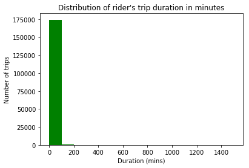

```python
# distribution of duration of trips
bins = np.arange(1, clean_gobike['duration_mins'].max()+100, 100)
plt.hist(data = clean_gobike, x = 'duration_mins', bins = bins, facecolor = 'g')
plt.title("Distribution of rider's trip duration in minutes")
plt.xlabel('Duration (mins)')
plt.ylabel('Number of trips');
```

```python
# log type numerical statistics for duration
np.log10(clean_gobike.duration_mins.describe())
```

```
count    5.242919
mean     1.069423
std      1.437276
min      0.008600
25%      0.730782
50%      0.929419
75%      1.118926
max      3.148951
Name: duration_mins, dtype: float64
```

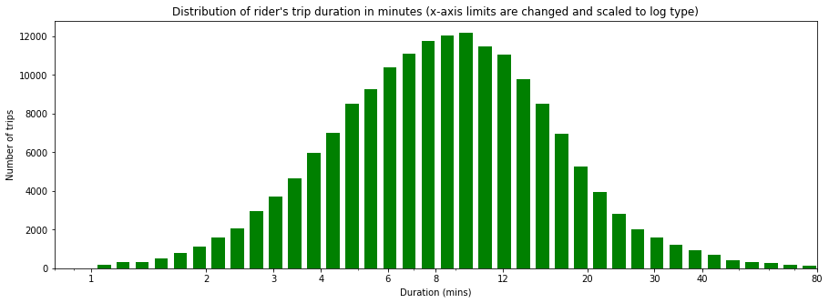

```python
# distribution of duration of trips using log transformation
plt.figure(figsize = (15, 5))
bins = 10 ** np.arange(0.008, 3.2+0.05, 0.05)
plt.hist(data = clean_gobike, x = 'duration_mins', bins = bins, facecolor = 'g', rwidth = .7)
ticker = [0, 1, 2, 3, 4, 6, 8, 12, 20, 30, 40, 80]
label = ['{}'.format(v) for v in ticker]
plt.xscale('log')
plt.xticks(ticker, label)
plt.xlim((0.8, 80))
plt.title("Distribution of rider's trip duration in minutes (x-axis limits are changed and scaled to log type)")
plt.xlabel('Duration (mins)')
plt.ylabel('Number of trips');
```

Most trips were completed between 5 to 13 minutes.

##### What station gained the most traffic?

```python
# number of stations present in our data set and their frequency
num = clean_gobike['start_station_name'].value_counts().count()
print('\033[32mThere are {} stations present in our dataset\n'.format(num))
clean_gobike['start_station_name'].value_counts()
```

```
There are 329 stations present in our dataset
```

```
Market St at 10th St                                               3649
San Francisco Caltrain Station 2  (Townsend St at 4th St)          3408
Berry St at 4th St                                                 2952
Montgomery St BART Station (Market St at 2nd St)                   2711
Powell St BART Station (Market St at 4th St)                       2620
San Francisco Caltrain (Townsend St at 4th St)                     2577
San Francisco Ferry Building (Harry Bridges Plaza)                 2541
Howard St at Beale St                                              2216
Steuart St at Market St                                            2191
Powell St BART Station (Market St at 5th St)                       2144
The Embarcadero at Sansome St                                      1975
Bancroft Way at Telegraph Ave                                      1761
Bancroft Way at College Ave                                        1712
2nd St at Townsend St                                              1702
Beale St at Harrison St                                            1678
3rd St at Townsend St                                              1675
Embarcadero BART Station (Beale St at Market St)                   1646
4th St at Mission Bay Blvd S                                       1496
Townsend St at 7th St                                              1479
Civic Center/UN Plaza BART Station (Market St at McAllister St)    1476
The Embarcadero at Steuart St                                      1420
Downtown Berkeley BART                                             1322
Post St at Kearny St                                               1311
4th St at 16th St                                                  1274
Howard St at 8th St                                                1257
19th Street BART Station                                           1231
Esprit Park                                                        1226
Rhode Island St at 17th St                                         1224
Hearst Ave at Euclid Ave                                           1176
8th St at Brannan St                                               1154
                                                                   ...
27th St at MLK Jr Way                                                54
45th St at MLK Jr Way                                                54
Mendell St at Fairfax Ave                                            53
San Antonio Park                                                     53
Locust St at Grant St                                                49
Williams Ave at 3rd St                                               48
Delmas Ave and San Fernando St                                       47
San Carlos St at Market St                                           37
Lane St at Revere Ave                                                36
Foothill Blvd at Harrington Ave                                      35
Mission St at 1st St                                                 32
Almaden Blvd at Balbach St                                           32
George St at 1st St                                                  31
Oak St at 1st St                                                     30
Empire St at 7th St                                                  28
SAP Center                                                           27
Williams Ave at Apollo St                                            25
Foothill Blvd at 42nd Ave                                            23
San Pedro St at Hedding St                                           19
26th Ave at International Blvd                                       19
Backesto Park (Jackson St at 13th St)                                17
23rd Ave at Foothill Blvd                                            17
Leavenworth St at Broadway                                           16
Taylor St at 9th St                                                  13
Willow St at Vine St                                                  9
Farnam St at Fruitvale Ave                                            9
Parker Ave at McAllister St                                           7
21st Ave at International Blvd                                        4
Palm St at Willow St                                                  3
16th St Depot                                                         2
Name: start_station_name, Length: 329, dtype: int64
```

```python
# create a subset of first 10 station names with highest frequency
station = ['Market St at 10th St', 'San Francisco Caltrain Station 2  (Townsend St at 4th St)', 'Berry St at 4th St', 'Montgomery St BART Station (Market St at 2nd St)',
           'Powell St BART Station (Market St at 4th St)', 'San Francisco Caltrain (Townsend St at 4th St)', 'San Francisco Ferry Building (Harry Bridges Plaza)',
           'Howard St at Beale St', 'Steuart St at Market St', 'Powell St BART Station (Market St at 5th St)']
gobike10 = clean_gobike.loc[clean_gobike['start_station_name'].isin(station)]
```

```python
# number of start stations present in our subset data set and their frequency
num = gobike10['start_station_name'].value_counts().count()
print('\033[32mThere are {} start stations present in our dataset\n'.format(num))
gobike10['start_station_name'].value_counts()
```

```
There are 10 start stations present in our dataset
```

```
Market St at 10th St                                         3649
San Francisco Caltrain Station 2  (Townsend St at 4th St)    3408
Berry St at 4th St                                           2952
Montgomery St BART Station (Market St at 2nd St)             2711
Powell St BART Station (Market St at 4th St)                 2620
San Francisco Caltrain (Townsend St at 4th St)               2577
San Francisco Ferry Building (Harry Bridges Plaza)           2541
Howard St at Beale St                                        2216
Steuart St at Market St                                      2191
Powell St BART Station (Market St at 5th St)                 2144
Name: start_station_name, dtype: int64
```

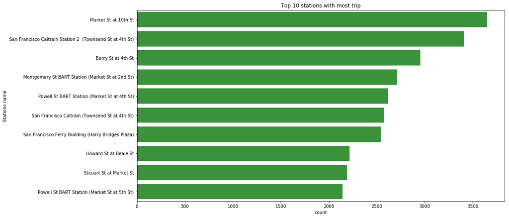

```python
# create a countplot for top 10 stations
ordr = gobike10.start_station_name.value_counts().index
plt.figure(figsize = (15, 8))
colour = sb.color_palette()[2]
sb.countplot(data = gobike10, y = 'start_station_name', color = colour, order = ordr)
plt.title('Top 10 stations with most trip')
plt.ylabel('Stations name');
```

Market St at 10th St station has the most trips. From Google Map, this could be as a result of the station being located around Tourist sites and business hubs. Also present are a number of train stations. The second busiest station is San Francisco Caltrain Station 2 (Townsend St at 4th St). Tourist sites and business hubs could also a reason for it busy nature.

##### With regards to our top 10 station, at what time duration did most riders complete their trips

```python
# log type numerical statistics for duration
np.log10(gobike10.duration_mins.describe())
```

```
count    4.431509
mean     1.077315
std      1.442709
min      0.008600
25%      0.810904
50%      0.963788
75%      1.106191
max      3.148951
Name: duration_mins, dtype: float64
```

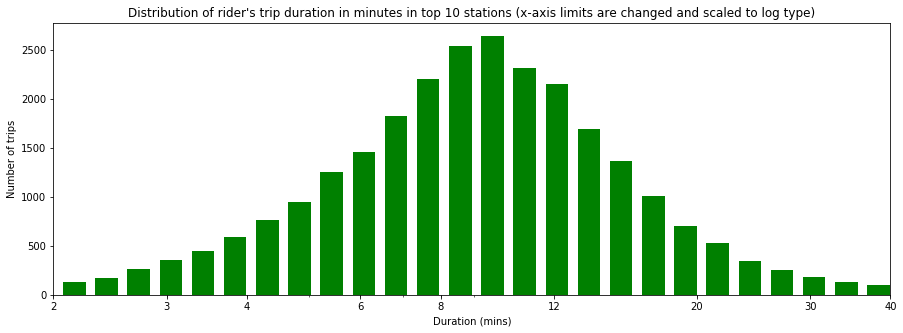

```python
# lets plot the distribution of duration of trips for our top 10 stations with huge traffic using log transformation
plt.figure(figsize = (15, 5))
bins = 10 ** np.arange(0.008, 3.2+0.05, 0.05)
plt.hist(data = gobike10, x = 'duration_mins', bins = bins, facecolor = 'g', rwidth = .7)
ticker = [0, 1, 2, 3, 4, 6, 8, 12, 20, 30, 40, 80]
label = ['{}'.format(v) for v in ticker]
plt.xscale('log')
plt.xticks(ticker, label)
plt.xlim((2, 40))
plt.title("Distribution of rider's trip duration in minutes in top 10 stations (x-axis limits are changed and scaled to log type)")
plt.xlabel('Duration (mins)')
plt.ylabel('Number of trips');
```

Most of the trip are completed at an average duration of 8 to 12 minutes. This sort of correspond with our earlier plot of duration distribution for our over all dataset

##### What is the age range for most riders?

```python
# numerical statistics for age
gobike10.age.describe()
```

```
count    27009.000000
mean        35.014736
std         10.238980
min         18.000000
25%         28.000000
50%         33.000000
75%         40.000000
max        141.000000
Name: age, dtype: float64
```

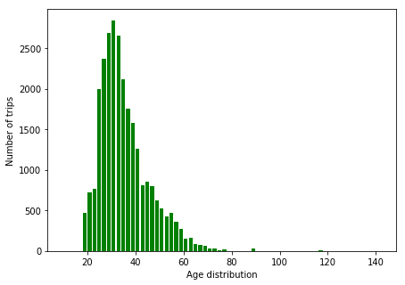

```python
# age distribution in top 10 stations
plt.figure(figsize = (7, 5))
bins = np.arange(10, gobike10.age.max()+2, 2)
plt.hist(data = gobike10, x = 'age', bins = bins, facecolor = 'g', rwidth = 0.8)
plt.xlabel('Age distribution')
plt.ylabel('Number of trips');

# from our plot, we can see that our data is skewed to the right. This shows a need for our axis transformation
```

```python
np.log10(gobike10.age.describe())
```

```
count    4.431509
mean     1.544251
std      1.010257
min      1.255273
25%      1.447158
50%      1.518514
75%      1.602060
max      2.149219
Name: age, dtype: float64
```

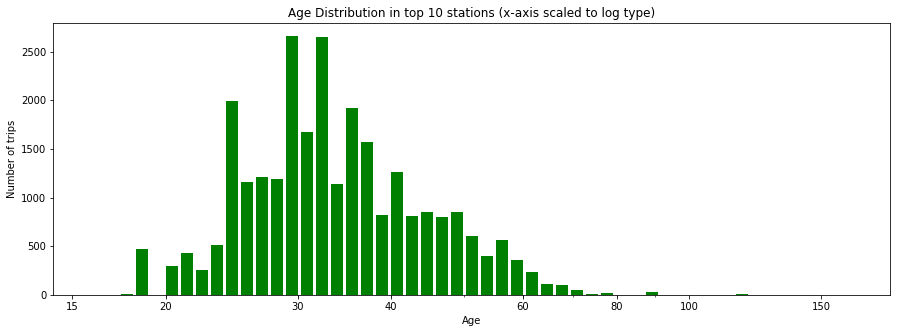

```python
# age distribution in top 10 station using log scale for the x-axis transformation
plt.figure(figsize = (15, 5))
bins = 10 ** np.arange(1.2, 2.2+0.02, 0.02)
plt.hist(data = gobike10, x = 'age', bins = bins, facecolor = 'g', rwidth = 0.8)
plt.xscale('log')
ticker = [15, 20, 30, 40, 60, 80, 100, 150]
plt.xticks(ticker, ticker)
plt.title('Age Distribution in top 10 stations (x-axis scaled to log type)')
plt.xlabel('Age')
plt.ylabel('Number of trips');
```

From our plot, most trips in the top 10 stations are completed by persons around age 30. It appears there are persons of age 100 and above which i believe are outliers.

##### What day do riders prefer most?

```python
print(gobike10['start_day'].describe())
gobike10['end_day'].describe()
```

```
count        27009
unique           7
top       Thursday
freq          5591
Name: start_day, dtype: object
```

```
count        27009
unique           7
top       Thursday
freq          5594
Name: end_day, dtype: object
```

```python
print(gobike10['start_day'].value_counts())
gobike10['end_day'].value_counts()
```

```
Thursday     5591
Tuesday      5203
Wednesday    4789
Friday       4618
Monday       4175
Saturday     1407
Sunday       1226
Name: start_day, dtype: int64
```

```
Thursday     5594
Tuesday      5204
Wednesday    4788
Friday       4614
Monday       4173
Saturday     1405
Sunday       1231
Name: end_day, dtype: int64
```

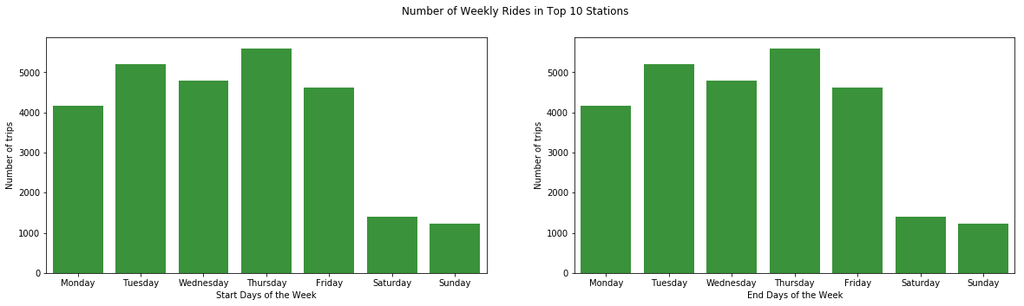

```python
# distribution of riders at a particular time
plt.figure(figsize = (20, 5))
plt.suptitle('Number of Weekly Rides in Top 10 Stations')
plt.subplot(1, 2, 1)
colour = sb.color_palette()[2]
sb.countplot(data = gobike10, x = 'start_day', color = colour)
plt.xlabel('Start Days of the Week')
plt.ylabel('Number of trips')

plt.subplot(1, 2, 2)
sb.countplot(data = gobike10, x = 'end_day', color = colour)
plt.xlabel('End Days of the Week')
plt.ylabel('Number of trips');
```

Weekdays appears to have more riders than weekends with Thursday and Tuesday having the highest number of rides. Monday have the least ride for the weekdays. What could be the reasons behind this?

##### What time of the day do most riders prefer?

```python
gobike10.day_period.describe()
```

```
count       27009
unique          3
top       morning
freq        11443
Name: day_period, dtype: object
```

```python
gobike10.day_period.value_counts()
```

```
morning      11443
afternoon     9749
night         5817
Name: day_period, dtype: int64
```

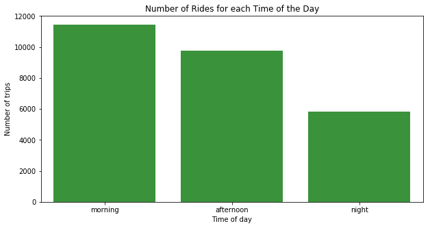

```python
# time of the day distribution in top 10 stations
plt.figure(figsize = (10, 5))
sb.countplot(data = gobike10, x = 'day_period', color = colour)
plt.title('Number of Rides for each Time of the Day')
plt.xlabel('Time of day')
plt.ylabel('Number of trips');
```

From our plot, riders make the most trip during the morning and afternoon hours. This could be as a result of working hours duration. Night appears to be the period for least trip.

##### What gender and user type make the most trip?

```python
print(gobike10.member_gender.value_counts())
print(gobike10.user_type.value_counts())
```

```
Male      20432
Female     6128
Other       449
Name: member_gender, dtype: int64
Subscriber    24499
Customer       2510
Name: user_type, dtype: int64
```

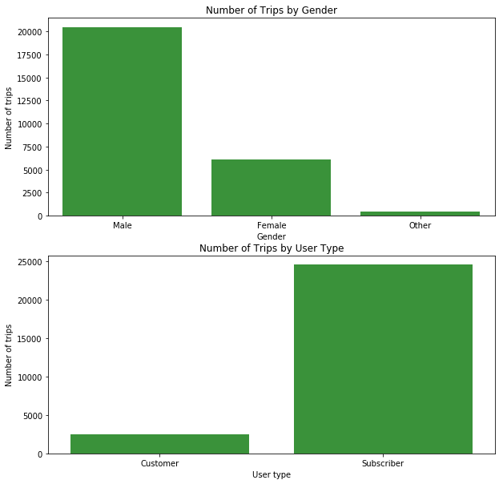

```python
# plot distribution of gender and user type
fig, ax = plt.subplots(nrows = 2, figsize = [10, 10])
sb.countplot(data = gobike10, x = 'member_gender', color = colour, ax = ax[0])
sb.countplot(data = gobike10, x = 'user_type', color = colour, ax = ax[1])
ax[0].set_title('Number of Trips by Gender')
ax[0].set_xlabel('Gender')
ax[0].set_ylabel('Number of trips')
ax[1].set_title('Number of Trips by User Type')
ax[1].set_xlabel('User type')
ax[1].set_ylabel('Number of trips');
```

> 1. From our plot, male have the most trip than female, while 'other' have the least ride. What reasons could be behind male riders getting more rides than women rider? "Other" variable could be as a result of riders that neither identify as male or female.
> 2. From our user type plot, suscribers tend to have the most trip than customers. This could be as a result of greater priority which the company have for subscribers than customers.

### Discuss the distribution(s) of your variable(s) of interest. Were there any unusual points? Did you need to perform any transformations?

> After performing cleaning operation on our dataset, we had 174952 data with 14 columns. To avoid over plotting, I created a subset of top 10 stations location with highest ride frequendy to lowest ride frequency that I will be working with. They include;
> 1. 'Market St at 10th St',
> 2. 'San Francisco Caltrain Station 2 (Townsend St at 4th St)',
> 3. 'Berry St at 4th St',
> 4. 'Montgomery St BART Station (Market St at 2nd St)',
> 5. 'Powell St BART Station (Market St at 4th St)',
> 6. 'San Francisco Caltrain (Townsend St at 4th St)',
> 7. 'San Francisco Ferry Building (Harry Bridges Plaza)',
> 8. 'Howard St at Beale St',
> 9. 'Steuart St at Market St',
> 10. 'Powell St BART Station (Market St at 5th St)'

> The duration for complete trip and age were skewed to the right. To correct this, i performed a log transformation on these variables and found out that most trips were completed in 8 to 12 minutes range, while the average age of most riders was around 30. Weekdays tend to be the favourite days for riders with Thursday and Tuesday having the most trips, while mondays have least trips for weekdays. This needs to be investigated further. Riders make the most trip during the morning and afternoon hours of the day. This should be as a result of working hours duration. Night appears to be the period with least rides. For Users, males have the most trip than female and other. Subcribers tend to have the most trip than customers.

### Of the features you investigated, were there any unusual distributions? Did you perform any operations on the data to tidy, adjust, or change the form of the data? If so, why did you do this?

> There were 183412 data present in the dataset with 16 columns. The dataset was a bit dirty and messy.
> 1. There was year of birth present instead of age. I performed a lambda arithmetic operation on the column series and created a new age column for the dataset.
> 2. From the start time column, I extracted the month, Day of the weeks, and time of the day into different columns.
> 3. The month extracted from start time column happens to be February.
> 4. The time duration for a complete ride was presented in seconds which was not clear enough. The least time duration was 61 seconds which is a 1.1minutes duration. I converted the duration to minutes which is a proper representation of seconds.
> 5. Columns that we will not be working with for our analysis were discarded including the month column
> 6. There were some missing data in our datasets too. The rows containing these missing data were dropped.
> 7. Erroneous data type was addressed too.

## Bivariate Exploration

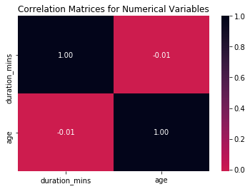

```python
# correlation matrices for numerical variables
sb.heatmap(gobike10.corr(), annot = True, fmt = '.2f', cmap = 'rocket_r', center = 0)
plt.title('Correlation Matrices for Numerical Variables');
```

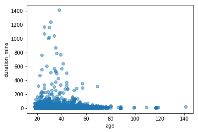

```python
# relationship between duration and age
sb.regplot(data = gobike10, x = 'age', y = 'duration_mins', fit_reg = False, scatter_kws = {'alpha': 1/2});
```

```python
def log_trans(x, inverse = False):
    """ Transformation Helper Function """
    if not inverse:
        return np.log10(x)
    else:
        return np.power(10, x)
```

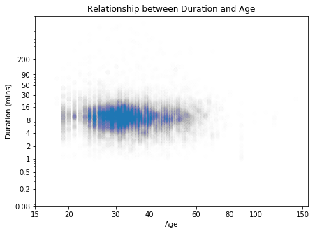

```python
# log transformation for both age and duration
plt.figure(figsize = (7, 5))
gobike10['log_age'] = gobike10['age'].apply(log_trans)
sb.regplot(data = gobike10, x = 'log_age', y = 'duration_mins', fit_reg = False, scatter_kws = {'alpha': 1/500})
plt.yscale('log')
xtick = [15, 20, 30, 40, 60, 80, 100, 150]
label = ['{}'.format(v) for v in xtick]
plt.xticks(log_trans(xtick), label)
ytick = [0.08, 0.2, 0.5, 1, 2, 4, 8, 16, 30, 50, 90, 200]
plt.yticks(ytick, ytick)
plt.title('Relationship between Duration and Age')
plt.xlabel('Age')
plt.ylabel('Duration (mins)');
```

From the correlation matrices for numerical variables, age and duration have a slight negative correlation. Most riders were around age greater than 20 and less than 40. this put it at an average of around 30 years. The time duration for this age was around 10 minutes.

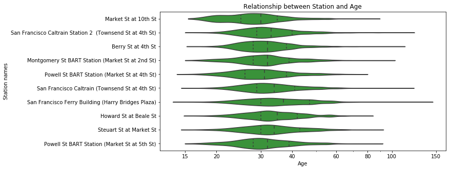

```python
# plot for station and age
plt.figure(figsize = (10, 5))
sb.violinplot(data = gobike10, x = 'age', y = 'start_station_name', color = colour, inner = 'quartile', order = ordr)
plt.xscale('log')
xticker = [15, 20, 30, 40, 60, 80, 100, 150]
label = ['{}'.format(v) for v in xticker]
plt.xticks(xticker, label)
plt.title('Relationship between Station and Age')
plt.xlabel('Age')
plt.ylabel('Station names');
```

Age have a median of around 30 years for all top 10 station location. This further shows that the majority of riders around workable age of 30.

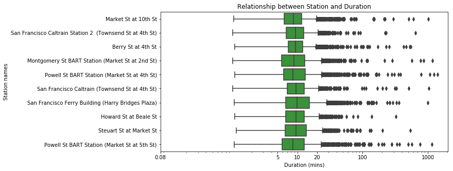

```python
# plot for station and duration
plt.figure(figsize = (10, 5))
sb.boxplot(data = gobike10, x = 'duration_mins', y = 'start_station_name', color = colour, order = ordr)
plt.xscale('log')
plt.xlabel('Duration (mins)');
ticker = [0.08, 5, 10, 20, 100, 1000]
plt.xticks(ticker, ticker)
plt.title('Relationship between Station and Duration')
plt.ylabel('Station names');
```

Duration have a median of around 10 minutes for all top 10 station location. This corresponds to our earlier plot on the duration of riders.

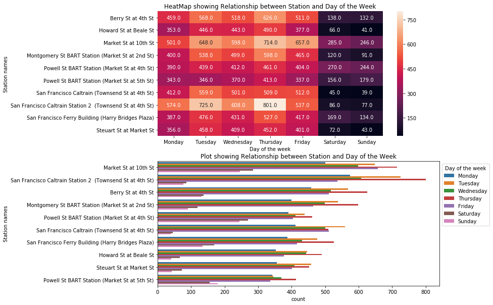

```python
# relationship between station and day of the week
plt.figure(figsize = (10, 10))

plt.subplot(2, 1, 1)
cat_count = gobike10.groupby(['start_station_name', 'start_day']).size()
cat_count = cat_count.reset_index(name = 'count').pivot(index = 'start_station_name', columns = 'start_day', values = 'count')
sb.heatmap(cat_count, annot = True, fmt = '.1f')
plt.title('HeatMap showing Relationship between Station and Day of the Week')
plt.xlabel('Day of the week')
plt.ylabel('Station names')

plt.subplot(2, 1, 2)
sb.countplot(data = gobike10, y = 'start_station_name', hue = 'start_day', order = ordr)
plt.legend(bbox_to_anchor = (1, 1))
plt.legend(bbox_to_anchor = (1, 1), title = 'Day of the week')
plt.title('Plot showing Relationship between Station and Day of the Week')
plt.ylabel('Station names');
```

In all 10 locations, weekdays have most rides than weekends. Among the weekdays, thursday and tuesday have the most trips, while monday have the least trip. What could be the reason behind this? Unlike the former distribution of station plot that made Market St at 10th St the station with the most rides, this plot gives a better insight. San Francisco Caltrain Station 2 (Townsend St at 4th St) and Market St at 10th St have the most ride for weekdays, but Market St at 10th St have most rides for weekends as well as Powell St BART Station (Market St at 4th St).

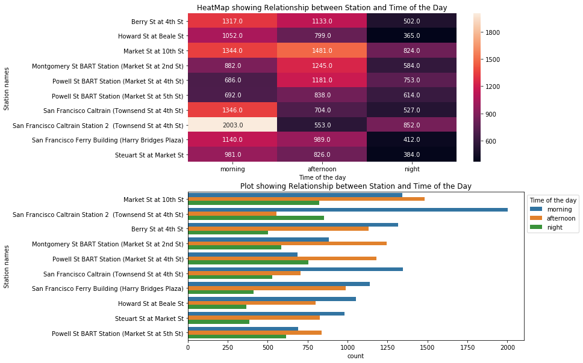

```python
# relationship between station and time of the day
plt.figure(figsize = (10, 10))

plt.subplot(2, 1, 1)
cat_count = gobike10.groupby(['start_station_name', 'day_period']).size()
cat_count = cat_count.reset_index(name = 'count').pivot(index = 'start_station_name', columns = 'day_period', values = 'count')
sb.heatmap(cat_count, annot = True, fmt = '.1f');
plt.title('HeatMap showing Relationship between Station and Time of the Day')
plt.xlabel('Time of the day')
plt.ylabel('Station names')

plt.subplot(2, 1, 2)
sb.countplot(data = gobike10, y = 'start_station_name', hue = 'day_period', order = ordr)
plt.legend(bbox_to_anchor = (1, 1), title = 'Time of the day')
plt.title('Plot showing Relationship between Station and Time of the Day')
plt.ylabel('Station names');
```

Morning and Afternoon have the most ride for the top 10 stations. San Francisco Caltrain Station 2 (Townsend St at 4th St) have the most ride for morning. This is different for Market St at 10th St that have almost equal rides for both afternoon and morning period.

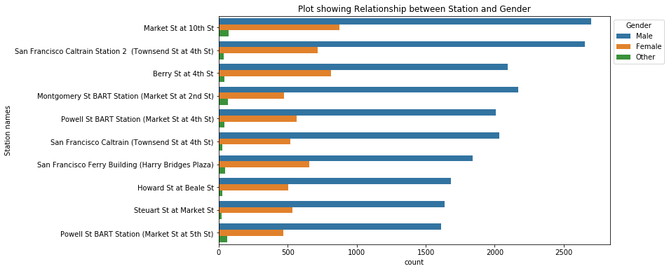

```python
# relationship between station and gender
plt.figure(figsize=(10,6))
sb.countplot(data = gobike10, y = 'start_station_name', hue = 'member_gender', order = ordr)
plt.legend(bbox_to_anchor = (1, 1), title = 'Gender')
plt.title('Plot showing Relationship between Station and Gender')
plt.ylabel('Station names');
```

Across all top 10 station, male have most rides than female. From our earlier plot on the distribution of gender, we still haven't figured out why the male gender are more than the female.

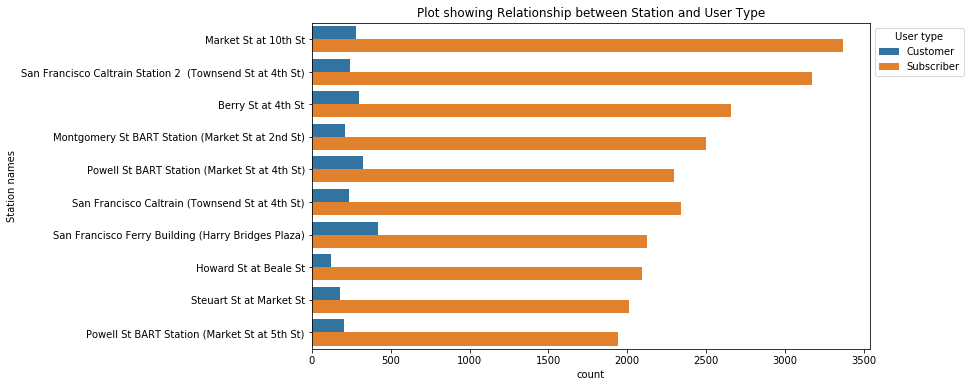

```python
# relationship between station and user type
plt.figure(figsize=(10,6))
sb.countplot(data = gobike10, y = 'start_station_name', hue = 'user_type', order = ordr)
plt.legend(bbox_to_anchor = (1, 1), title = 'User type')
plt.title('Plot showing Relationship between Station and User Type')
plt.ylabel('Station names');
```

Subscribers tends to have more rides than customers. Market St at 10th St have the most suscribers.

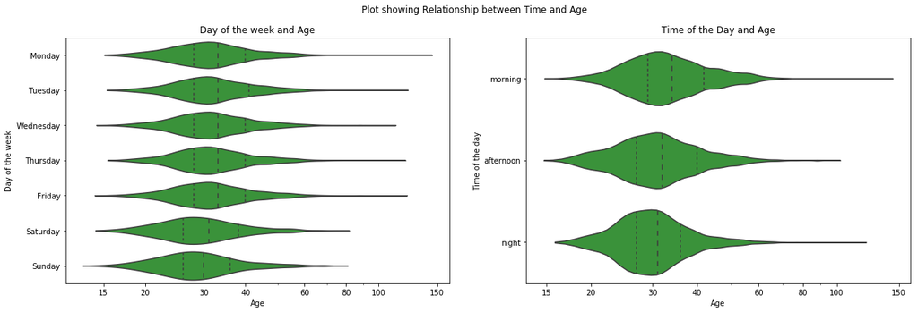

```python
# relationship plot between time and age
plt.figure(figsize = (20, 6))
plt.suptitle('Plot showing Relationship between Time and Age')

plt.subplot(1, 2, 1)
sb.violinplot(data = gobike10, x = 'age', y = 'start_day', color = colour, inner = 'quartile')
plt.xscale('log')
xticker = [15, 20, 30, 40, 60, 80, 100, 150]
label = ['{}'.format(v) for v in xticker]
plt.xticks(xticker, label)
plt.title('Day of the week and Age')
plt.ylabel('Day of the week')
plt.xlabel('Age');

plt.subplot(1, 2, 2)
sb.violinplot(data = gobike10, x = 'age', y = 'day_period', color = colour, inner = 'quartile')
plt.xscale('log')
xticker = [15, 20, 30, 40, 60, 80, 100, 150]
label = ['{}'.format(v) for v in xticker]
plt.xticks(xticker, label)
plt.title('Time of the Day and Age')
plt.ylabel('Time of the day')
plt.xlabel('Age');
```

The median age for most riders during the weekdays are slightly higher than those of weekends, but they are still around the range of 30. This shows that more younger people ride during the weekends. This further proves the age of most riders to be around 30.

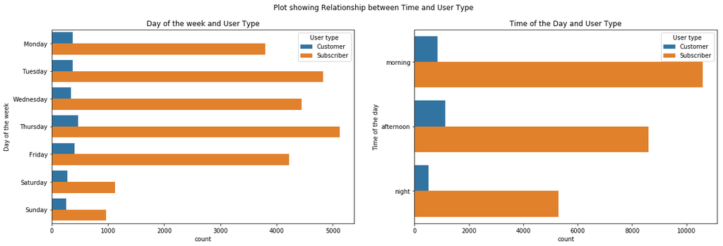

```python
# plot of user type against time
plt.figure(figsize = (20, 6))
plt.suptitle('Plot showing Relationship between Time and User Type')

plt.subplot(1, 2, 1)
sb.countplot(data = gobike10, y = 'start_day', hue = 'user_type')
plt.legend(bbox_to_anchor = (1, 1), title = 'User type')
plt.title('Day of the week and User Type')
plt.ylabel('Day of the week');

plt.subplot(1, 2, 2)
sb.countplot(data = gobike10, y = 'day_period', hue = 'user_type')
plt.legend(bbox_to_anchor = (1, 1), title = 'User type')
plt.title('Time of the Day and User Type')
plt.ylabel('Time of the day');
```

Subcribers tend to ride mostly on thursday and tuesdays. what is happening on thurdays and tuesdays? We need to investigate further. Morning hours also have the most ride for subscribers, while afternoon hours have most ride for customers.

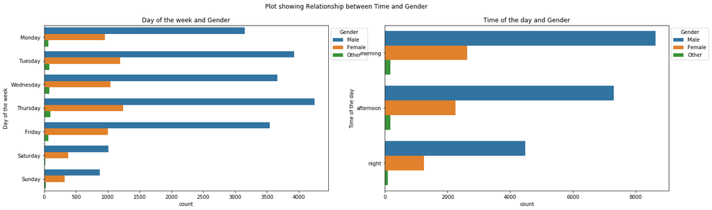

```python
# plot of gender and time
plt.figure(figsize = (22, 6))
plt.suptitle('Plot showing Relationship between Time and Gender')

plt.subplot(1, 2, 1)
sb.countplot(data = gobike10, y = 'start_day', hue = 'member_gender')
plt.legend(bbox_to_anchor = (1, 1), title = 'Gender')
plt.title('Day of the week and Gender')
plt.ylabel('Day of the week');

plt.subplot(1, 2, 2)
sb.countplot(data = gobike10, y = 'day_period', hue = 'member_gender')
plt.legend(bbox_to_anchor = (1, 1), title = 'Gender')
plt.title('Time of the day and Gender')
plt.ylabel('Time of the day');
```

This also confirms earlier plot that male have more rides than females and others and they have most rides in the morning hours.

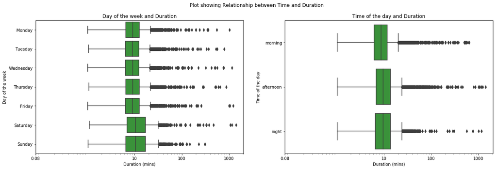

```python
# plot between time and duration
plt.figure(figsize = (20, 6))
plt.suptitle('Plot showing Relationship between Time and Duration')

plt.subplot(1, 2, 1)
sb.boxplot(data = gobike10, x = 'duration_mins', y = 'start_day', color = colour)
plt.xscale('log')
ticker = [0.08, 10, 100, 1000]
plt.xticks(ticker, ticker)
plt.title('Day of the week and Duration')
plt.ylabel('Day of the week')
plt.xlabel('Duration (mins)');

plt.subplot(1, 2, 2)
sb.boxplot(data = gobike10, x = 'duration_mins', y = 'day_period', color = colour)
plt.xscale('log')
ticker = [0.08, 10, 100, 1000]
plt.xticks(ticker, ticker);
plt.title('Time of the day and Duration')
plt.ylabel('Time of the day')
plt.xlabel('Duration (mins)');
```

From our plot, weekends have the longest duration of rides than weekdays. Afternoon and night also have longer duration of rides than morning

### Talk about some of the relationships you observed in this part of the investigation. How did the feature(s) of interest vary with other features in the dataset?

> Age of riders for the Top 10 stations have a median of around 30. This further shows that the majority of riders are around workable age of 30.

> Duration have a median of around 10 minutes for all top 10 station location. This corresponds to our earlier plot on the duration of riders

> In all 10 locations, weekdays have most rides than weekends. Among the weekdays, thursday and tuesday have the most trips, while monday have the least trip. Unlike the former distribution of station plot that made Market St at 10th St the station with the most rides, this plot gives a better insight. San Francisco Caltrain Station 2 (Townsend St at 4th St) and Market St at 10th St have the most ride for weekdays, especially thursdays and tuesdays, but Market St at 10th St have most rides for weekends which i believe could be as a result of tourist presence. This could suggest that Market St at 10th St have much more attractive sites than San Francisco Caltrain Station 2 (Townsend St at 4th St).

> Morning and Afternoon have the most ride for the top 10 stations. San Francisco Caltrain Station 2 (Townsend St at 4th St) have the most ride for morning. This is different for Market St at 10th St that have almost equal rides for both afternoon and morning period. This further strengthens our assumption on Market St at 10th St been made up of employees and tourists.

> Male have most rides than female.

> Subscribers tends to have more rides than customers. Market St at 10th St have the most suscribers.

> The median age for most riders during the weekdays are slightly higher than those of weekends, but they are still around the range of 30. This shows that more younger people ride during the weekends. This further proves the age of most riders to be around 30.

> Subcribers tend to ride mostly on thursday and tuesdays. what is happening on thurdays and tuesdays? We need to investigate further. Morning hours also have the most ride for subscribers, while afternoon hours have most ride for customers.

> Male have more rides than females and others and they have most rides in the morning hours.

> Weekends have the longest duration of rides than weekdays. Afternoon and night also have longer duration of rides than morning

### Did you observe any interesting relationships between the other features (not the main feature(s) of interest)?

> There was a negative relationship between age and duration. Riders with age average of 30 have the most rides with duration of around 10 minutes.

## Multivariate Exploration

```python
# create a subset of individual gender and user type to investigate time and station location
gobike_m = gobike10.query('member_gender == "Male"')
gobike_f = gobike10.query('member_gender == "Female"')
gobike_o = gobike10.query('member_gender == "Other"')
gobike_s = gobike10.query('user_type == "Subscriber"')
gobike_c = gobike10.query('user_type == "Customer"')
```

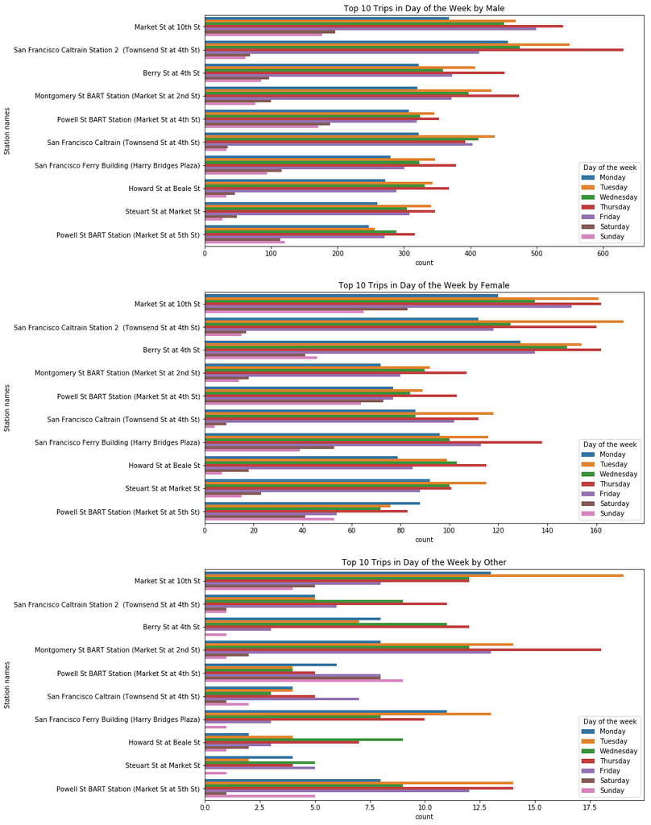

```python
# plot of gender with station name and day of the week
plt.figure(figsize = (12, 22))

plt.subplot(3, 1, 1)
sb.countplot(data = gobike_m, y = 'start_station_name', hue = 'start_day', order = ordr)
plt.legend(title = 'Day of the week')
plt.ylabel('Station names')
plt.title('Top 10 Trips in Day of the Week by Male')

plt.subplot(3, 1, 2)
sb.countplot(data = gobike_f, y = 'start_station_name', hue = 'start_day', order = ordr)
plt.legend(title = 'Day of the week')
plt.ylabel('Station names')
plt.title('Top 10 Trips in Day of the Week by Female')

plt.subplot(3, 1, 3)
sb.countplot(data = gobike_o, y = 'start_station_name', hue = 'start_day', order = ordr)
plt.legend(title = 'Day of the week')
plt.ylabel('Station names')
plt.title('Top 10 Trips in Day of the Week by Other');
```

Weekdays have most riders than than Weekends for both male, female and other with thursday and tuesday having the highest ride count. Market St at 10th St have most rides for weekends than San Francisco Caltrain Station 2 (Townsend St at 4th St).

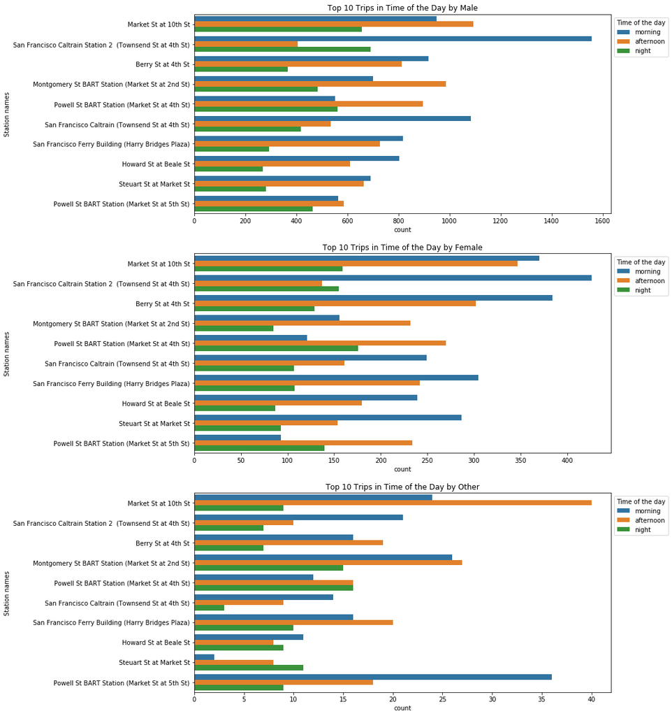

```python
# plot of gender with station name and time of the day
plt.figure(figsize = (12, 20))

plt.subplot(3, 1, 1)
sb.countplot(data = gobike_m, y = 'start_station_name', hue = 'day_period', order = ordr)
plt.legend(bbox_to_anchor = (1, 1), title = 'Time of the day')
plt.ylabel('Station names');
plt.title('Top 10 Trips in Time of the Day by Male')

plt.subplot(3, 1, 2)
sb.countplot(data = gobike_f, y = 'start_station_name', hue = 'day_period', order = ordr)
plt.legend(bbox_to_anchor = (1, 1), title = 'Time of the day')
plt.ylabel('Station names');
plt.title('Top 10 Trips in Time of the Day by Female')

plt.subplot(3, 1, 3)
sb.countplot(data = gobike_o, y = 'start_station_name', hue = 'day_period', order = ordr)
plt.legend(bbox_to_anchor = (1, 1), title = 'Time of the day')
plt.ylabel('Station names')
plt.title('Top 10 Trips in Time of the Day by Other');
```

Morning and Afternoon have the most ride for all gender

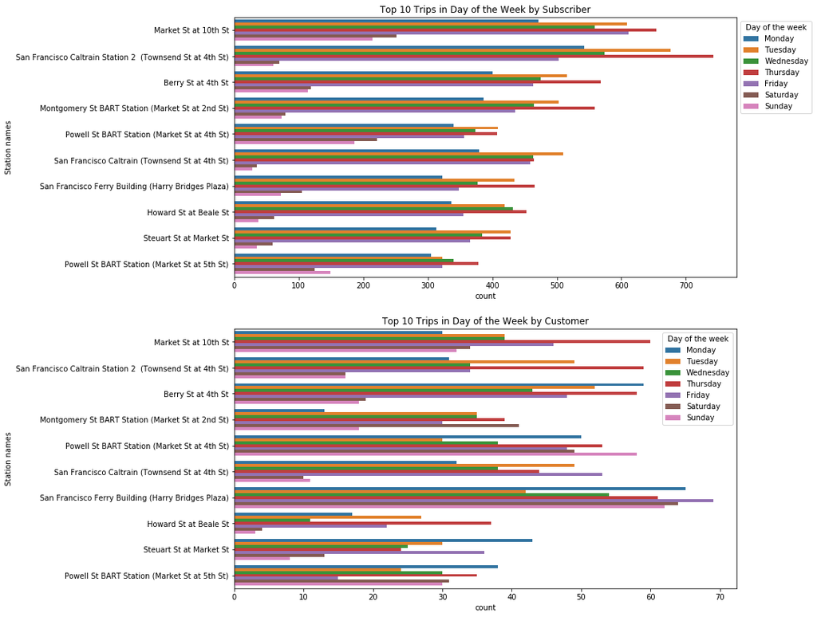

```python
# plot of user type with station name and day of the week
plt.figure(figsize = (12, 14))

plt.subplot(2, 1, 1)
sb.countplot(data = gobike_s, y = 'start_station_name', hue = 'start_day', order = ordr)
plt.legend(bbox_to_anchor = (1, 1))
plt.legend(bbox_to_anchor = (1, 1), title = 'Day of the week')
plt.ylabel('Station names');
plt.title('Top 10 Trips in Day of the Week by Subscriber')

plt.subplot(2, 1, 2)
sb.countplot(data = gobike_c, y = 'start_station_name', hue = 'start_day', order = ordr)
plt.legend(bbox_to_anchor = (1, 1))
plt.legend(bbox_to_anchor = (1, 1), title = 'Day of the week')
plt.ylabel('Station names')
plt.title('Top 10 Trips in Day of the Week by Customer');
```

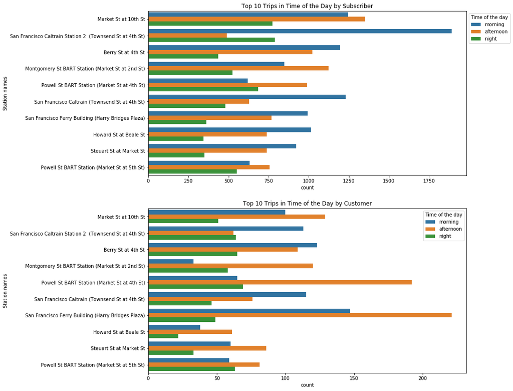

```python
# plot of user type with station name and time of the day
plt.figure(figsize = (12, 14))

plt.subplot(2, 1, 1)
sb.countplot(data = gobike_s, y = 'start_station_name', hue = 'day_period', order = ordr)
plt.legend(bbox_to_anchor = (1, 1), title = 'Time of the day')
plt.ylabel('Station names');
plt.title('Top 10 Trips in Time of the Day by Subscriber')

plt.subplot(2, 1, 2)
sb.countplot(data = gobike_c, y = 'start_station_name', hue = 'day_period', order = ordr)
plt.legend(bbox_to_anchor = (1, 1), title = 'Time of the day')
plt.ylabel('Station names')
plt.title('Top 10 Trips in Time of the Day by Customer');
```

Subscriber and customer have most trip for both morning and afternoon.

```python
# does age and duration determine when riders make trip? We will be using station id instead of station name for our FacetGrid plot
print(gobike10.groupby('start_station_name')['start_station_id'].value_counts())
order = gobike10.start_station_id.value_counts().index
```

```
start_station_name                                         start_station_id
Berry St at 4th St                                         81                  2952
Howard St at Beale St                                      22                  2216
Market St at 10th St                                       58                  3649
Montgomery St BART Station (Market St at 2nd St)           21                  2711
Powell St BART Station (Market St at 4th St)               3                   2620
Powell St BART Station (Market St at 5th St)               5                   2144
San Francisco Caltrain (Townsend St at 4th St)             30                  2577
San Francisco Caltrain Station 2  (Townsend St at 4th St)  67                  3408
San Francisco Ferry Building (Harry Bridges Plaza)         15                  2541
Steuart St at Market St                                    16                  2191
Name: start_station_id, dtype: int64
```

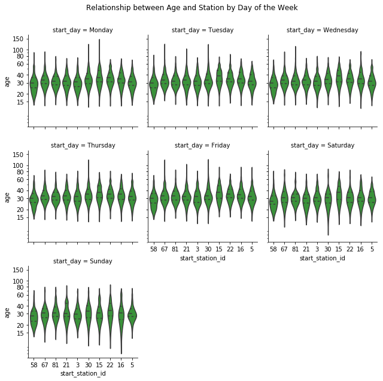

```python
# plot of the age by day of the week in top 10 stations
g = sb.FacetGrid(data = gobike10, col = 'start_day', col_wrap = 3)
g.map(sb.violinplot, 'start_station_id', 'age', order = order, color = colour, inner = 'quartile');
plt.yscale('log');
ticker = [15, 20, 30, 40, 60, 80, 100, 150]
plt.yticks(ticker, ticker)
g.fig.subplots_adjust(top=0.9)
g.fig.suptitle('Relationship between Age and Station by Day of the Week');
```

The relationship between age and station by day of the week have a median of around 30 years. This is not different from our earlier discovery

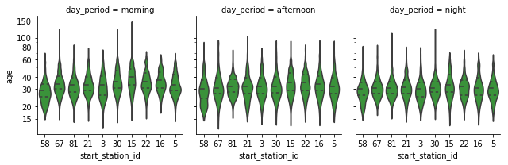

```python
# plot of the age by time of the day in top 10 stations
g = sb.FacetGrid(data = gobike10, col = 'day_period', col_wrap = 3)
g.map(sb.violinplot, 'start_station_id', 'age', order = order, color = colour, inner = 'quartile')
plt.yscale('log')
ticker = [15, 20, 30, 40, 60, 80, 100, 150]
plt.yticks(ticker, ticker);
```

The relationship between age and station by time of the day also have a median of around 30 years.

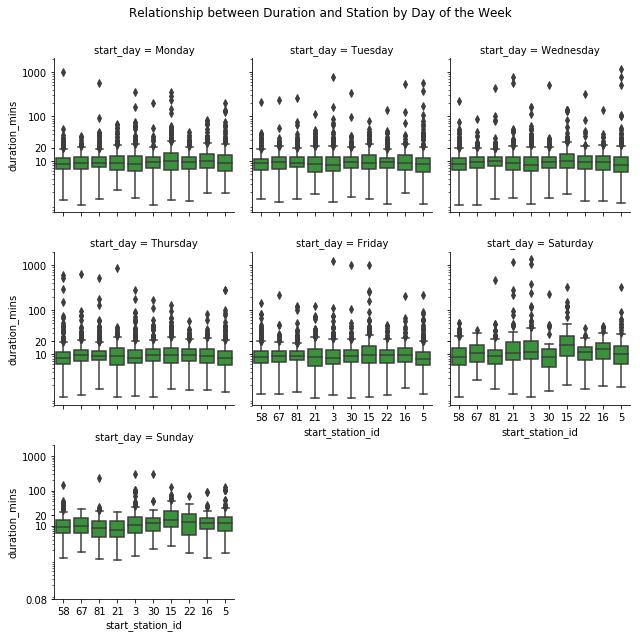

```python
# plot of the duration by day of the week in top 10 stations
g = sb.FacetGrid(data = gobike10, col = 'start_day', col_wrap = 3)
g.map(sb.boxplot, 'start_station_id', 'duration_mins', order = order, color = colour);
plt.yscale('log')
ticker = [0.08, 10, 20, 100, 1000]
plt.yticks(ticker, ticker)
g.fig.subplots_adjust(top=0.9)
g.fig.suptitle('Relationship between Duration and Station by Day of the Week');
```

The relationship between duration and station by day of the week shows that weekends have the longest duration for a complete trip. Weekdays still maintains 10 minutes as depicted on our earlier plot

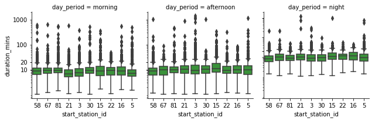

```python
# plot of the duration by time of the day in top 10 stations
g = sb.FacetGrid(data = gobike10, col = 'day_period', col_wrap = 3)
g.map(sb.boxplot, 'start_station_id', 'duration_mins', order = order, color = colour);
plt.yscale('log')
ticker = [0.08, 10, 20, 100, 1000]
plt.yticks(ticker, ticker);
```

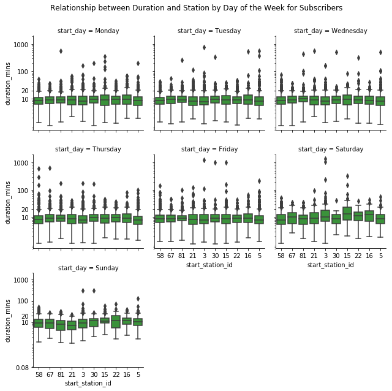

```python
# plot of the duration of subscribers trips by day of the week in top 10 stations
g = sb.FacetGrid(data = gobike_s, col = 'start_day', col_wrap = 3)
g.map(sb.boxplot, 'start_station_id', 'duration_mins', order = order, color = colour);
plt.yscale('log')
ticker = [0.08, 10, 20, 100, 1000]
plt.yticks(ticker, ticker)
g.fig.subplots_adjust(top=0.9)
g.fig.suptitle('Relationship between Duration and Station by Day of the Week for Subscribers');
```

Duration of subscribers trips by day of the week lies around 10mins for weekdays and a slight increase for weekends

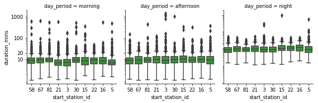

```python
# plot of the duration of subscribers trips by time of the day in top 10 stations
g = sb.FacetGrid(data = gobike_s, col = 'day_period', col_wrap = 3)
g.map(sb.boxplot, 'start_station_id', 'duration_mins', order = order, color = colour);
plt.yscale('log')
ticker = [0.08, 10, 20, 100, 1000]
plt.yticks(ticker, ticker);
```

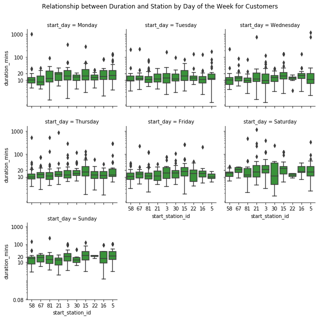

```python
# plot of the duration of customers trips by day of the week in top 10 stations
g = sb.FacetGrid(data = gobike_c, col = 'start_day', col_wrap = 3)
g.map(sb.boxplot, 'start_station_id', 'duration_mins', order = order, color = colour);
plt.yscale('log')
ticker = [0.08, 10, 20, 100, 1000]
plt.yticks(ticker, ticker)
g.fig.subplots_adjust(top=0.9)
g.fig.suptitle('Relationship between Duration and Station by Day of the Week for Customers');
```

Duration of customers trips by day of the week tends to be above 10mins for both weekdays and weekends

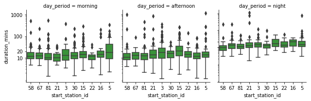

```python
# plot of the duration of customers trips by day of the week in top 10 stations
g = sb.FacetGrid(data = gobike_c, col = 'day_period', col_wrap = 3)
g.map(sb.boxplot, 'start_station_id', 'duration_mins', order = order, color = colour);
plt.yscale('log')
ticker = [0.08, 10, 20, 100, 1000]
plt.yticks(ticker, ticker);
```

### Talk about some of the relationships you observed in this part of the investigation. Were there features that strengthened each other in terms of looking at your feature(s) of interest?

> Plotting station location, time and riders characteristics (gender) gave more insights on station location. Market St at 10th St and San Francisco Caltrain Station 2 (Townsend St at 4th St) were ranked top two stations having the most traffic of over three thousand rides, with weekdays having the most rides than weekends. Comparing Market St at 10th St and San Francisco Caltrain Station 2 (Townsend St at 4th St) weekend rides showed that Market St at 10th St have most trips for weekends than San Francisco Caltrain Station 2 (Townsend St at 4th St).

## Conclusions

> Duration of trip for customers is longer than that of subscribers for every day of the week and time of the day.